# Lab for Week 3

January 30, 2019

# Lab This Week

For the lab this week, you will have to perform the following tasks.

1. You will individually:
   - create plots of a health dataset using ggplot()
   - generate “findings”
   - write a few sentences in the team report detailing what you did.
2. As a team, you will produce a lab report in R Markdown. The lab report will include:
   - an overall question you will answer using the health dataset
   - an explanation of why that question is important or interesting and a deeper explanation of why that reason(s) is/are important or interesting
   - one plot that visually “answers” the overall question
   - a “conclusion” or answer to the overall question in words
   - given your role as data scientists, you will provide a “recommendation” for action
   - a series of “findings” and plots based on individuals’ work that provides support for your overall conclusion and/or recommendation
   - a section detailing which team members did what

Much of the lab this week will focus on plotting. We will get you started with some of the awesome things you can do with ggplot().

# Resource:

**ggplot cheat sheet:** https://www.rstudio.com/wp-content/uploads/2015/03/ggplot2-cheatsheet.pdf

# ggplot

Let’s load the tidyverse package, which contains ggplot inside of it.

```r
library(tidyverse)
```

Now we need a dataset to work with. We will use the mtcars dataset, which is automatically built into R

```r
?mtcars         # Information about the data
data(mtcars)    # Load the built-in data
head(mtcars)    # View first few rows of data
```

```
##                    mpg cyl disp  hp drat    wt  qsec vs am gear carb
## Mazda RX4         21.0   6  160 110 3.90 2.620 16.46  0  1    4    4
## Mazda RX4 Wag     21.0   6  160 110 3.90 2.875 17.02  0  1    4    4
## Datsun 710        22.8   4  108  93 3.85 2.320 18.61  1  1    4    1
## Hornet 4 Drive    21.4   6  258 110 3.08 3.215 19.44  1  0    3    1
## Hornet Sportabout 18.7   8  360 175 3.15 3.440 17.02  0  0    3    2
## Valiant           18.1   6  225 105 2.76 3.460 20.22  1  0    3    1
```

```r
str(mtcars)     # Structure of the data
```

```
## 'data.frame':    32 obs. of  11 variables:
##  $ mpg : num  21 21 22.8 21.4 18.7 18.1 14.3 24.4 22.8 19.2 ...
##  $ cyl : num  6 6 4 6 8 6 8 4 4 6 ...
##  $ disp: num  160 160 108 258 360 ...
##  $ hp  : num  110 110 93 110 175 105 245 62 95 123 ...
##  $ drat: num  3.9 3.9 3.85 3.08 3.15 2.76 3.21 3.69 3.92 3.92 ...
##  $ wt  : num  2.62 2.88 2.32 3.21 3.44 ...
##  $ qsec: num  16.5 17 18.6 19.4 17 ...
##  $ vs  : num  0 0 1 1 0 1 0 1 1 1 ...
##  $ am  : num  1 1 1 0 0 0 0 0 0 0 ...
##  $ gear: num  4 4 4 3 3 3 3 4 4 4 ...
##  $ carb: num  4 4 1 1 2 1 4 2 2 4 ...
```

```r
summary(mtcars) # Summary of the data
```

```
##       mpg             cyl             disp             hp
##  Min.   :10.40   Min.   :4.000   Min.   : 71.1   Min.   : 52.0
##  1st Qu.:15.43   1st Qu.:4.000   1st Qu.:120.8   1st Qu.: 96.5
##  Median :19.20   Median :6.000   Median :196.3   Median :123.0
##  Mean   :20.09   Mean   :6.188   Mean   :230.7   Mean   :146.7
##  3rd Qu.:22.80   3rd Qu.:8.000   3rd Qu.:326.0   3rd Qu.:180.0
##  Max.   :33.90   Max.   :8.000   Max.   :472.0   Max.   :335.0
##       drat             wt             qsec             vs
##  Min.   :2.760   Min.   :1.513   Min.   :14.50   Min.   :0.0000
##  1st Qu.:3.080   1st Qu.:2.581   1st Qu.:16.89   1st Qu.:0.0000
##  Median :3.695   Median :3.325   Median :17.71   Median :0.0000
##  Mean   :3.597   Mean   :3.217   Mean   :17.85   Mean   :0.4375
##  3rd Qu.:3.920   3rd Qu.:3.610   3rd Qu.:18.90   3rd Qu.:1.0000
##  Max.   :4.930   Max.   :5.424   Max.   :22.90   Max.   :1.0000
##        am              gear            carb
##  Min.   :0.0000   Min.   :3.000   Min.   :1.000
##  1st Qu.:0.0000   1st Qu.:3.000   1st Qu.:2.000
##  Median :0.0000   Median :4.000   Median :2.000
##  Mean   :0.4062   Mean   :3.688   Mean   :2.812
##  3rd Qu.:1.0000   3rd Qu.:4.000   3rd Qu.:4.000
##  Max.   :1.0000   Max.   :5.000   Max.   :8.000
```

Now it’s time to begin plotting. Here is the general format for a ggplot.

### Format for a ggplot

```r
# How to make a ggplot
ggplot(data = "data_frame", aes(x = "x_variable", y = "y_variable", color/fill = "another_variable")) +
  "geometry" +
  "whatever_other_layers_you_want"
```

### Example 1: A basic histogram with title and labels

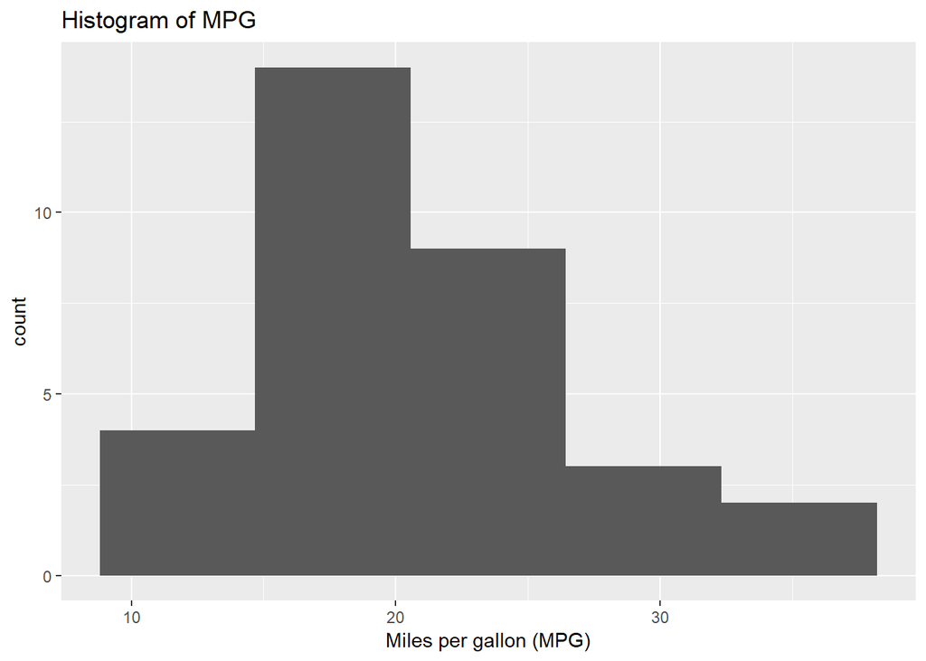

```r
# Histogram of miles per gallon
ggplot(data = mtcars, aes(x = mpg)) +  # Build a graph
  geom_histogram(bins = 5) +           # Add a histogram layer
  ggtitle('Histogram of MPG') +        # Plot title
  xlab('Miles per gallon (MPG)')       # x-label title
```

### Example 2: A scatter plot, grouped by a third variable

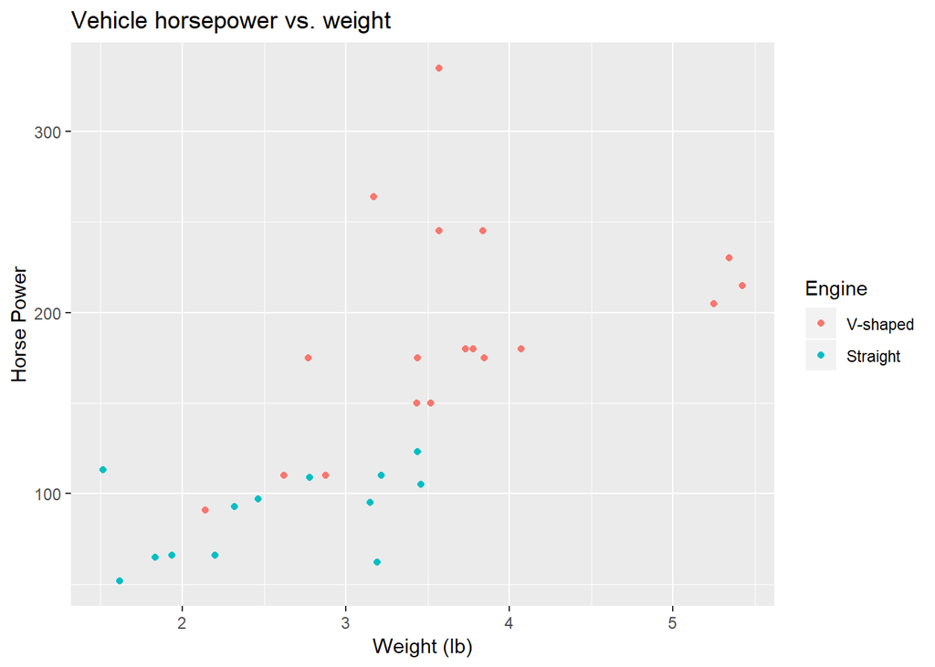

```r
# Histogram of miles per gallon
ggplot(data = mtcars, aes(x = wt, y = hp, color = as.factor(vs))) +  # Build a graph
  geom_point() +                                                     # Add a scatter plot
  ggtitle('Vehicle horsepower vs. weight') +                         # Plot title
  xlab('Weight (lb)') +                                              # x-label title
  ylab('Horse Power') +                                              # y-lable title
  scale_color_discrete(name = 'Engine',                              # Edit legend
                       labels = c('V-shaped', 'Straight'))
```

### Example 3: A box plot of number of gears vs. MPG, with other layers

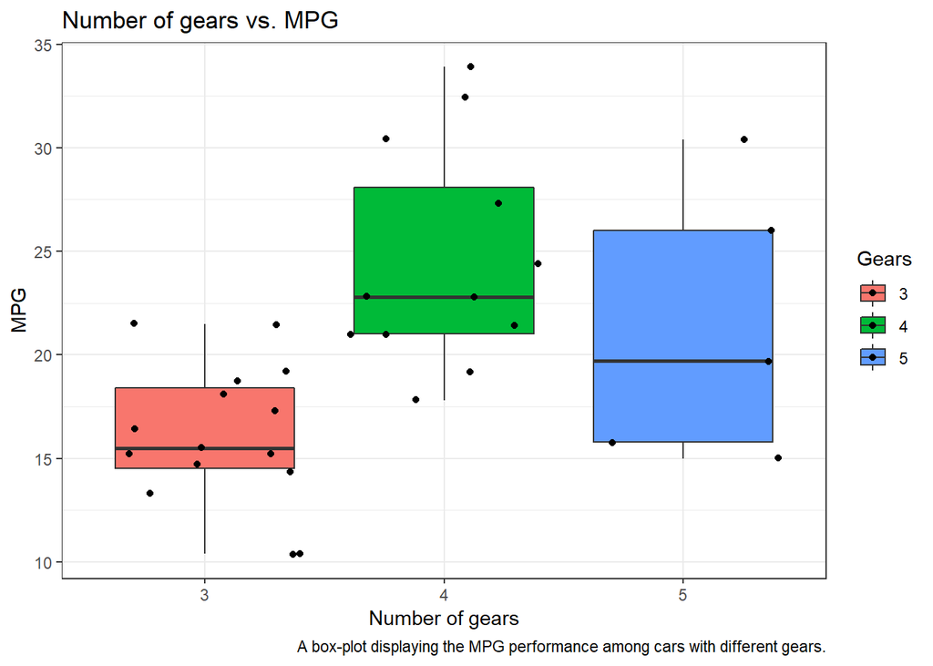

```r
# Histogram of miles per gallon
ggplot(data = mtcars, aes(x = as.factor(gear), y = mpg, fill = as.factor(gear))) +  # Build a graph
  geom_boxplot() +                                                                  # Add boxplot layer
  geom_point(position = 'jitter') +                                                 # Add points w/ position adjust
  ggtitle('Number of gears vs. MPG') +                                              # Plot title
  xlab('Number of gears') +                                                         # x-label title
  ylab('MPG') +                                                                     # y-label title
  scale_fill_discrete(name = 'Gears',                                               # Edit legend
                       labels = c(3,4,5)) +
  theme_bw() +                                                                      # Black and white theme
  labs(caption = "A box-plot displaying the MPG performance among cars with different gears.") # Caption
```

# How intense can ggplot get?

```r
# Example of an intense ggplot
ggplot(data = prop_data, aes(x = Age, y = Correct)) +                                 # Build a graph
  geom_point() +                                                                      # Add scatter plot geometry
  ggtitle('Proportion Correct vs. Age') +                                             # Add title
  xlab('Age') +                                                                       # Change x-label
  ylab('Proportion Correct') +                                                        # Change y-label
  geom_smooth(method = 'lm') +                                                        # Add best-fit line
  scale_x_continuous(trans='log10',                                                   # x-axis in log10 scale
                     breaks = seq(2,7.5,by=1/4),                                      # x-tick spacing
                     labels = c(2, rep("",3), 3, rep("",3), 4, rep("",3),             # x-tick labels
                                5, rep("",3), 6, rep("",3), 7, rep("",2)),
                     limits = c(2,7.5),                                               # x-scale limits
                     sec.axis = dup_axis(labels = rep("", length(seq(2,7.5,by=1/4))), # Add axis to top of plot
                                         name = "")) +
  scale_y_continuous(breaks= seq(.84,1,by=.01),                                       # y-tick spacing
                     labels = c(.84, "", .86, "", .88, "", .90, "",                   # y-tick labels
                                .92, "", .94, "", .96, "", .98, "", 1.00),
                     limits = c(.84,1),                                               # y-scale limits
                     oob=scales::rescale_none,                                        # Don't remember what this does
                     sec.axis = dup_axis(labels = rep("", 17), name = "")) +          # Add axis to right of plot
  geom_point(data = subject6, aes(x = Age, y = Correct), color = 'red') +             # Add red point from other data
  theme_bw() +                                                                        # Black and white background
  theme(text = element_text(size=16),                                                 # Title text size
        axis.text.x = element_text(size = 16),                                        # x-label text size
        axis.text.y = element_text(size = 16),                                        # y-label text size
        panel.grid.major = element_blank(),                                           # Can't remember
        panel.grid.minor = element_blank())                                           # Can't remember
```